# Usage

```r
library(dplyr)
library(sf)
```

```r
library(mapview)
library(viridis)
library(spatialData)
library(spatialFolds)
```

```r
data("vi")
data("interaction")
data("trees")
```

# Cast functions

These functions cast POINT `sf` dataframes and `xy` data frames.

## `cast_df_to_sf()`

Transforms a data frame with coordinate columns to a POINT `sf` dataframe.

```r
#build xy dataframe
vi_xy <- vi |>
  sf::st_coordinates() |>
  as.data.frame()

head(vi_xy)
```

```
#>            X         Y
#> 1 -114.25431 45.054027
#> 2  114.84569 26.270694
#> 3 -122.14597 56.379027
#> 4  108.37069 29.945694
#> 5   19.09569  9.262361
#> 6  111.72903 25.779027
```

```r
vi_sf <- spatialFolds::cast_df_to_sf(
  df = vi_xy
)

vi_sf
```

```
#> Simple feature collection with 9265 features and 2 fields
#> Geometry type: POINT
#> Dimension:     XY
#> Bounding box:  xmin: -139.0876 ymin: -52.97931 xmax: 178.3624 ymax: 59.62903
#> Geodetic CRS:  WGS 84
#> First 10 features:
#>             X          Y                    geometry
#> 1  -114.25431  45.054027  POINT (-114.2543 45.05403)
#> 2   114.84569  26.270694   POINT (114.8457 26.27069)
#> 3  -122.14597  56.379027   POINT (-122.146 56.37903)
#> 4   108.37069  29.945694   POINT (108.3707 29.94569)
#> 5    19.09569   9.262361   POINT (19.09569 9.262361)
#> 6   111.72903  25.779027    POINT (111.729 25.77903)
#> 7   149.08736  -9.245973  POINT (149.0874 -9.245973)
#> 8    22.71236 -27.454306  POINT (22.71236 -27.45431)
#> 9   105.46236  31.579027   POINT (105.4624 31.57903)
#> 10  -44.97931 -11.162639 POINT (-44.97931 -11.16264)
```

## `cast_sf_to_xy()`

Extracts a two-column `xy` matrix from an `sf` dataframe. For POLYGON geometries, centroids are used.

```r
vi_xy_matrix <- cast_sf_to_xy(vi)
head(vi_xy_matrix)
```

```
#>               x         y
#> [1,] -114.25431 45.054027
#> [2,]  114.84569 26.270694
#> [3,] -122.14597 56.379027
#> [4,]  108.37069 29.945694
#> [5,]   19.09569  9.262361
#> [6,]  111.72903 25.779027
```

```r
# Also works on polygons (uses centroids)
trees_xy <- cast_sf_to_xy(trees)
head(trees_xy)
```

```
#>              x        y
#> [1,] -124.8289 43.24583
#> [2,] -124.8289 48.44180
#> [3,] -124.3289 40.64783
#> [4,] -124.3289 42.37983
#> [5,] -124.3289 44.11183
#> [6,] -124.3289 45.84382
```

## `cast_sf_to_bbox()`

Extracts the bounding box of an `sf` object as a one-row rectangular polygon `sf` dataframe.

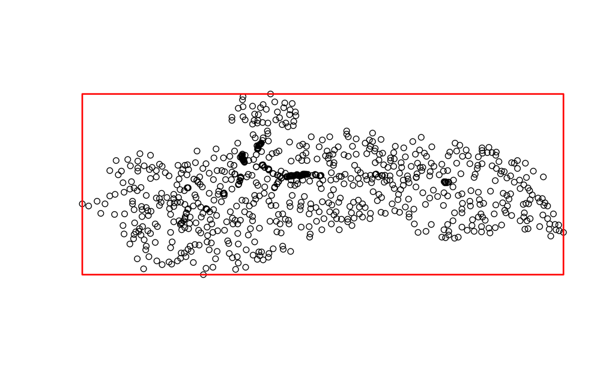

```r
interaction_bbox <- cast_sf_to_bbox(interaction)

plot(sf::st_geometry(interaction))
plot(sf::st_geometry(interaction_bbox), add = TRUE, border = "red", lwd = 2)
```

## `cast_xy_to_xyz()`

Converts longitude/latitude coordinates to 3D Cartesian coordinates on a unit sphere. This eliminates discontinuities at the dateline and poles.

```r
vi_xyz <- cast_xy_to_xyz(vi_xy_matrix[1:5, ])
round(vi_xyz, 3)
```

```
#>           x      y     z
#> [1,] -0.290 -0.644 0.708
#> [2,] -0.377  0.814 0.443
#> [3,] -0.295 -0.469 0.833
#> [4,] -0.273  0.822 0.499
#> [5,]  0.933  0.323 0.161
```

```r
# North pole convergence: all longitudes map to the same point
pole_xy <- cbind(x = c(0, 90, 180), y = c(90, 90, 90))
round(cast_xy_to_xyz(pole_xy), 3)  # all rows identical at (0, 0, 1)
```

```
#>      x y z
#> [1,] 0 0 1
#> [2,] 0 0 1
#> [3,] 0 0 1
```

# Utility functions

## `utils_needs_spherical()`

Analyzes coordinate ranges (in degrees) to determine whether spherical geometry should be used. Returns `TRUE` for global data near the dateline or poles.

```r
# vi is in EPSG:4326 degrees and spans globally — returns TRUE
utils_needs_spherical(vi_xy_matrix)
```

```
#> [1] TRUE
```

```r
# Local geographic coordinates in degrees — returns FALSE
local_xy <- cbind(x = runif(100, -5, 5), y = runif(100, 40, 45))
utils_needs_spherical(local_xy)
```

```
#> [1] FALSE
```

```r
# Compute interaction_xy for use in later examples
# Note: interaction is in EPSG:25830 (UTM meters)
interaction_xy <- cast_sf_to_xy(interaction)
```

# Spatial Thinning

## `spatial_thinning()`

Resamples points to enforce minimum distance separation or reach a target sample size.

```r
# Auto-calculated distance
vi_thinned_auto <- spatial_thinning(df = vi)
```

```
#>
#> spatialFolds::spatial_thinning()
#> └── spatialFolds::validate_arg_distance(): Auto-calculated distance = 0.982133
```

```r
nrow(vi_thinned_auto)
```

```
#> [1] 3423
```

```r
# Fixed distance (degrees)
vi_thinned_dist <- spatial_thinning(df = vi, distance = 5)
nrow(vi_thinned_dist)
```

```
#> [1] 286
```

```r
# Target number of points
vi_thinned_target <- spatial_thinning(df = vi, target = 300)
nrow(vi_thinned_target)
```

```
#> [1] 292
```

## `thinning_to_distance()`

C++ function applying greedy sequential thinning with a fixed minimum distance. Returns indices of retained points.

```r
# interaction is in UTM meters; use 500 m as minimum separation distance
retained <- thinning_to_distance(xy = interaction_xy, distance = 500)
length(retained)
```

```
#> [1] 673
```

## `thinning_to_target()`

C++ function applying iterative thinning using binary search on distance until the target count is reached. Returns indices of retained points.

```r
retained_t <- thinning_to_target(xy = interaction_xy, target = 200L)
length(retained_t)
```

```
#> [1] 196
```

# Spatial Folds

## `spatial_folds()`

Generates training/testing folds for spatial cross-validation. Returns a data frame with one logical column per fold.

```r
# All three methods, single training fraction
folds <- spatial_folds(
  df = interaction,
  methods = c("contiguous", "random", "blocks"),
  training_fraction = 0.75,
  repetitions = 5,
  seed = 1
)
```

```
#>
#> spatialFolds::spatial_folds(): Using spherical geometry to generate contiguous folds.
#> 9
#> └── spatialFolds::block_ids()
#>     └── spatialFolds::validate_arg_blocks(): using 4 blocks for the 'blocks' method.
```

```r
dim(folds)
```

```
#> [1] 1000   15
```

```r
names(folds)
```

```
#>  [1] "contiguous_0.75_1" "contiguous_0.75_2" "contiguous_0.75_3"
#>  [4] "contiguous_0.75_4" "contiguous_0.75_5" "random_0.75_1"
#>  [7] "random_0.75_2"     "random_0.75_3"     "random_0.75_4"
#> [10] "random_0.75_5"     "blocks_0.75_1"     "blocks_0.75_2"
#> [13] "blocks_0.75_3"     "blocks_0.75_4"     "blocks_0.75_5"
```

```r
# Multiple training fractions
folds_multi <- spatial_folds(
  df = interaction,
  methods = "random",
  training_fraction = c(0.75, 0.5),
  repetitions = 3,
  seed = 1
)
names(folds_multi)
```

```
#> [1] "random_0.75_1" "random_0.75_2" "random_0.75_3" "random_0.50_1"
#> [5] "random_0.50_2" "random_0.50_3"
```

## `deduplicate_folds()`

Removes highly correlated (redundant) folds within each method-fraction group.

```r
folds_many <- spatial_folds(
  df = interaction,
  methods = "contiguous",
  training_fraction = 0.75,
  repetitions = 20,
  seed = 1
)
```

```
#>
#> spatialFolds::spatial_folds(): Using spherical geometry to generate contiguous folds.
```

```r
ncol(folds_many)
```

```
#> [1] 20
```

```r
folds_deduped <- deduplicate_folds(folds_many)
```

```
#>
#> collinear::collinear_select()
#> └── collinear::validate_arg_preference_order()
#>     └── collinear::preference_order(): ranking 20 'predictors' from lower to higher multicollinearity.
#> spatialFolds::deduplicate_folds(): Reduced from 20 to 13 folds (7 redundant folds removed, 35% reduction)
```

```r
ncol(folds_deduped)
```

```
#> [1] 13
```

## `spatial_fold_plot()`

Visualizes one fold from a `spatial_folds()` result, showing training and testing samples.

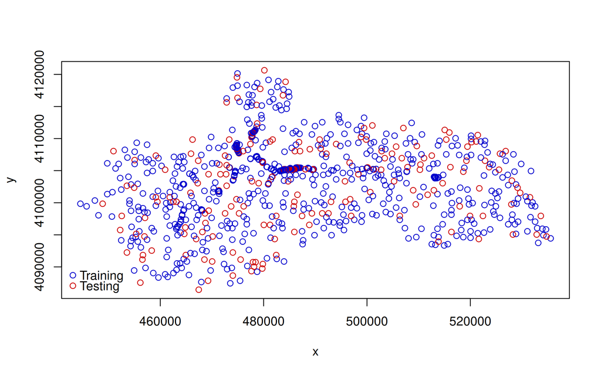

```r
spatial_fold_plot(
  df = interaction,
  training_fold = folds$contiguous_0.75_1
)
```

# Low-level fold methods

## `training_mask()`

Thin R wrapper that routes to the appropriate C++ method and returns a single logical training/testing vector.

```r
mask_random <- training_mask(
  xy = interaction_xy,
  method = "random",
  seed = 42L,
  target = 750L
)
sum(mask_random)
```

```
#> [1] 750
```

## `method_contiguous_planar()`

C++ function for contiguous training folds using planar (rectangular) geometry. Suitable for local to subcontinental data.

```r
x_range <- diff(range(interaction_xy[, "x"]))
y_range <- diff(range(interaction_xy[, "y"]))

fold_planar <- method_contiguous_planar(
  xy = interaction_xy,
  center = 1L,
  step_x = x_range / 1000,
  step_y = y_range / 1000,
  target = 750L
)
sum(fold_planar)
```

```
#> [1] 750
```

## `method_contiguous_spherical()`

C++ function for contiguous training folds using spherical (angular cap) geometry. Required for global data near the dateline or poles.

```r
vi_xy_matrix <- cast_sf_to_xy(vi)
vi_xyz <- cast_xy_to_xyz(vi_xy_matrix)
x_range_vi <- diff(range(vi_xy_matrix[, "x"]))
y_range_vi <- diff(range(vi_xy_matrix[, "y"]))
ang_step <- mean(c(x_range_vi, y_range_vi)) / 1000 * pi / 180

fold_sph <- method_contiguous_spherical(
  xyz = vi_xyz,
  center = 1L,
  angular_step = ang_step,
  target = 5000L
)
sum(fold_sph)
```

```
#> [1] 5000
```

## `method_random()`

C++ function for random data splitting using Fisher-Yates shuffle. Reproducible with a seed.

```r
fold_rnd <- method_random(
  xy = interaction_xy,
  seed = 42L,
  target = 750L
)
sum(fold_rnd)
```

```
#> [1] 750
```

## `method_blocks()`

```r
blocks_config <- validate_arg_blocks(blocks = NULL, df = interaction)
block_id_vec <- spatialFolds:::block_ids(interaction, blocks_config$rows, blocks_config$cols)
```

```
#> 9
#> └── spatialFolds::block_ids()
#>     └── spatialFolds::validate_arg_blocks(): using 4 blocks for the 'blocks' method.
```

```r
fold_blk <- method_blocks(
  xy = interaction_xy,
  block_id = block_id_vec,
  seed = 42L,
  target = 750L
)
sum(fold_blk)
```

[output not shown]

# Validation functions

## `validate_arg_sf()`

Validates `sf` or `data.frame` inputs, converting data frames to sf when needed.

```r
validated <- validate_arg_sf(df = interaction)
names(validated)   # returns the validated sf object
```

```
#>  [1] "butterfly"               "host_plant"
#>  [3] "class"                   "landsat_ndvi"
#>  [5] "landsat_pca_bands_123"   "landsat_pca_bands_457"
#>  [7] "rainfall_annual"         "solar_radiation"
#>  [9] "temperature_annual_mean" "temperature_summer_max"
#> [11] "temperature_winter_min"  "topographic_complexity"
#> [13] "topographic_position"    "geometry"
```

## `validate_arg_xy()`

```r
validate_arg_xy(xy = interaction_xy)  # silent on success
```

[output not shown]

[output cut: 986 more lines]

## `validate_arg_blocks()`

Validates the `blocks` argument and computes grid dimensions for the blocks method.

```r
blocks_auto <- validate_arg_blocks(blocks = NULL, df = interaction)
blocks_auto  # $rows, $cols
```

```
#> $rows
#> [1] 4
#>
#> $cols
#> [1] 9
#>
#> attr(,"validated")
#> [1] TRUE
```

```r
blocks_manual <- validate_arg_blocks(blocks = c(5L, 10L), df = interaction)
blocks_manual
```

```
#> $rows
#> [1] 5
#>
#> $cols
#> [1] 10
#>
#> attr(,"validated")
#> [1] TRUE
```

## `validate_arg_distance()`

Validates the `distance` argument for `spatial_thinning()`. Auto-calculates distance when `NULL`.

```r
dist_auto <- validate_arg_distance(df = interaction, distance = NULL)
```

```
#>
#> spatialFolds::validate_arg_distance(): Auto-calculated distance = 882.075391
```

```r
dist_auto
```

```
#>     xmax
#> 882.0754
```

## `validate_arg_target()`

Validates the `target` argument for `spatial_thinning()`.

```r
target_val <- validate_arg_target(df = interaction, target = 500L)
target_val
```

```
#> [1] 500
```